# ESM-232 Assignment 7

Rabbits and Hawks (Population Matrix)

Ruben Sanchez Ramirez, Julia Dagum, Bret Folger

May 17, 2021

#### **Background**

A small city with a large urban park has decided to introduce a rare species of rabbits into this park - Rabbits are cute and the kids love them, and giving a rare species a new home sounds like a good idea. The urban park manager is concerned about how this rabbit population might grow over the next few decades. Rabbits have no natural predators in the region where the park is situated. The manager would like to know, approximately, how many rabbits there will be 20 years from now if the rabbits are introduced as planned. The manager reviewed the literature and found the following estimates for survival and fertility rates for the rare rabbit population, for 4 different age classes. The estimates for these rates are shown below

**Fertility (rabbit/female) - Survivability**

- Young (Age 0-1) - 0 - 0.8
- Sub-Adults (Age 1-2) - 2 - 0.85
- Adult (Age 2-3) - 6 - 0.65
- Aged (Age 3-4) - 1 - 0.1

**Assume that we start with 10 adults rabbits.**

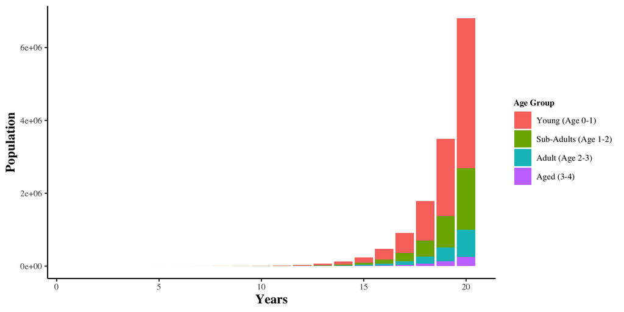

**Figure 1:** Yearly rabbit populations catagorized by age group. Total rabbit population ater 20 years with no predation during this period. The ration of each age group population to the overall total population.

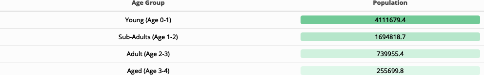

**Table 1:** Rabbit population of each age group after 20 years of growth with no predation. Color gradient showing the higher ration of the total population in darker colors.

#### **Sensitivity**

The park manager is also thinking of ways to keep the population under control - by encouraging nesting of hawks that eat the rabbits.

Hawks generally only eat younger rabbits- thus they reduce the survivability of the young and sub-adults age classes (the first two classes). The estimates are that survivability reduced to between 0.65 and 0.75 for Ages 0-1 and between 0.75 and 0.8 for Ages 1-2. We can assume that distributions are uniform.

A sensitivity analysis on the survivability of Young Age and Sub-Adults age class parameters was run using Sobel to generate variation in the survivability parameters. Then for each parameter set, total rabbit population after 20 years was calculated.

**Variation in total rabbit population.**

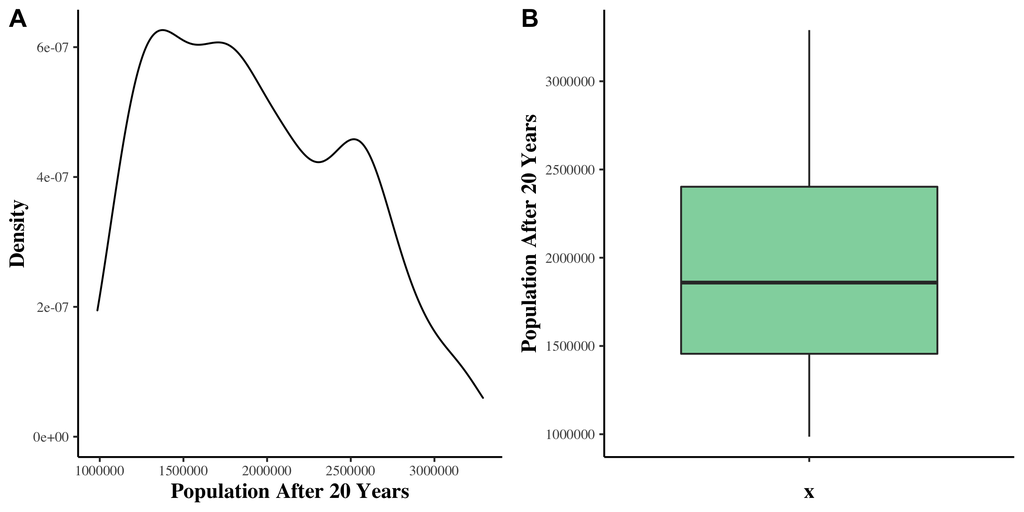

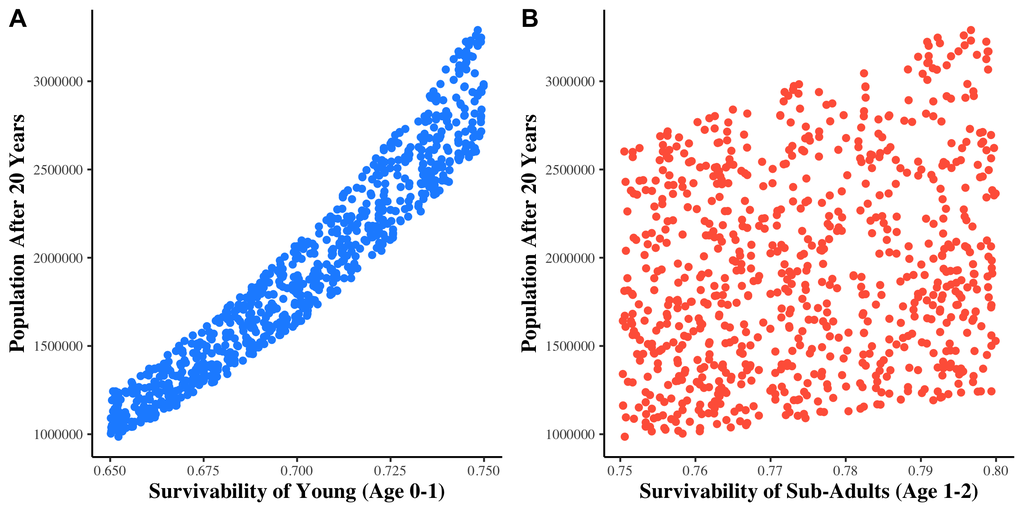

**Figure 3:** Total rabbit population after 20 years based on the survivability of two different age groups (Age 0-1, Age 1-2) when predator hawks are present. **(A)** The effect on total rabbit population after 20 years based on the sensitivity of young rabbits (Age 0-1) based on predation. **(B)** The effect on total rabbit population after 20 years based on the sensitivity of sub-adult rabbits (Age 1-2) based on predation

#### **Disscusion:**

How does this compare with total rabbit population after 20 years in your original population model (without the hawk related change to survivability)?